# Исследовательский анализ данных для интернет-магазина видеоигр

Необходимо провести анализ данных, предоставленных интернет-магазином видеоигр, и выявить закономерности, определяющие успешность игры.

## Загрузка библиотек

```python
import numpy as np
import pandas as pd
import matplotlib.pyplot as plt
import matplotlib.colors as mcolors
from scipy import stats
```

## Загрузка датасета

```python
data = pd.read_csv('/datasets/games.csv')

display(data.head())
display(data.info())
```

|  | Name | Platform | Year_of_Release | Genre | NA_sales | EU_sales | JP_sales | Other_sales | Critic_Score | User_Score | Rating |
| --- | --- | --- | --- | --- | --- | --- | --- | --- | --- | --- | --- |
| 0 | Wii Sports | Wii | 2006.0 | Sports | 41.36 | 28.96 | 3.77 | 8.45 | 76.0 | 8 | E |
| 1 | Super Mario Bros. | NES | 1985.0 | Platform | 29.08 | 3.58 | 6.81 | 0.77 | NaN | NaN | NaN |
| 2 | Mario Kart Wii | Wii | 2008.0 | Racing | 15.68 | 12.76 | 3.79 | 3.29 | 82.0 | 8.3 | E |
| 3 | Wii Sports Resort | Wii | 2009.0 | Sports | 15.61 | 10.93 | 3.28 | 2.95 | 80.0 | 8 | E |
| 4 | Pokemon Red/Pokemon Blue | GB | 1996.0 | Role-Playing | 11.27 | 8.89 | 10.22 | 1.00 | NaN | NaN | NaN |

```
<class 'pandas.core.frame.DataFrame'>
RangeIndex: 16715 entries, 0 to 16714
Data columns (total 11 columns):
 #   Column           Non-Null Count  Dtype
---  ------           --------------  -----
 0   Name             16713 non-null  object
 1   Platform         16715 non-null  object
 2   Year_of_Release  16446 non-null  float64
 3   Genre            16713 non-null  object
 4   NA_sales         16715 non-null  float64
 5   EU_sales         16715 non-null  float64
 6   JP_sales         16715 non-null  float64
 7   Other_sales      16715 non-null  float64
 8   Critic_Score     8137 non-null   float64
 9   User_Score       10014 non-null  object
 10  Rating           9949 non-null   object
dtypes: float64(6), object(5)
memory usage: 1.4+ MB
```

```
None
```

## Предобработка данных

```python
# Поиск явных строчек-дубликатов
data.duplicated().sum()
```

```
0
```

```python
# Переименование столбцов
name_list = []
for name in data.columns:
    name_list.append(name.lower())

data.columns = name_list

data.head()
```

|  | name | platform | year_of_release | genre | na_sales | eu_sales | jp_sales | other_sales | critic_score | user_score | rating |
| --- | --- | --- | --- | --- | --- | --- | --- | --- | --- | --- | --- |
| 0 | Wii Sports | Wii | 2006.0 | Sports | 41.36 | 28.96 | 3.77 | 8.45 | 76.0 | 8 | E |
| 1 | Super Mario Bros. | NES | 1985.0 | Platform | 29.08 | 3.58 | 6.81 | 0.77 | NaN | NaN | NaN |
| 2 | Mario Kart Wii | Wii | 2008.0 | Racing | 15.68 | 12.76 | 3.79 | 3.29 | 82.0 | 8.3 | E |
| 3 | Wii Sports Resort | Wii | 2009.0 | Sports | 15.61 | 10.93 | 3.28 | 2.95 | 80.0 | 8 | E |
| 4 | Pokemon Red/Pokemon Blue | GB | 1996.0 | Role-Playing | 11.27 | 8.89 | 10.22 | 1.00 | NaN | NaN | NaN |

```python
# Преданализ столбца названий
data[data['name'].isna()]
```

|  | name | platform | year_of_release | genre | na_sales | eu_sales | jp_sales | other_sales | critic_score | user_score | rating |
| --- | --- | --- | --- | --- | --- | --- | --- | --- | --- | --- | --- |
| 659 | NaN | GEN | 1993.0 | NaN | 1.78 | 0.53 | 0.00 | 0.08 | NaN | NaN | NaN |
| 14244 | NaN | GEN | 1993.0 | NaN | 0.00 | 0.00 | 0.03 | 0.00 | NaN | NaN | NaN |

Найдены 2 строчки с пропуском названий игры и не удалены, поскольку одна из них имеет значимые продажи и ее удаление может повлиять на данные.

```python
# Преданализ столбца про платформу
data['platform'].unique()
```

```
array(['Wii', 'NES', 'GB', 'DS', 'X360', 'PS3', 'PS2', 'SNES', 'GBA',
       'PS4', '3DS', 'N64', 'PS', 'XB', 'PC', '2600', 'PSP', 'XOne',
       'WiiU', 'GC', 'GEN', 'DC', 'PSV', 'SAT', 'SCD', 'WS', 'NG', 'TG16',
       '3DO', 'GG', 'PCFX'], dtype=object)
```

Неявных дубликатов в названии платформ не обнаружено.

```python
# Преданализ столбца про год выпуска
data['year_of_release'] = data['year_of_release'].apply(lambda x: pd.to_numeric(x, errors='coerce')).round().astype('Int64')
display(data['year_of_release'].unique())
display(data[data['year_of_release'].isna()].sort_values(by = 'na_sales', ascending = False).head())
```

```
<IntegerArray>
[2006, 1985, 2008, 2009, 1996, 1989, 1984, 2005, 1999, 2007, 2010, 2013, 2004,
 1990, 1988, 2002, 2001, 2011, 1998, 2015, 2012, 2014, 1992, 1997, 1993, 1994,
 1982, 2016, 2003, 1986, 2000, <NA>, 1995, 1991, 1981, 1987, 1980, 1983]
Length: 38, dtype: Int64
```

|  | name | platform | year_of_release | genre | na_sales | eu_sales | jp_sales | other_sales | critic_score | user_score | rating |
| --- | --- | --- | --- | --- | --- | --- | --- | --- | --- | --- | --- |
| 183 | Madden NFL 2004 | PS2 | <NA> | Sports | 4.26 | 0.26 | 0.01 | 0.71 | 94.0 | 8.5 | E |
| 609 | Space Invaders | 2600 | <NA> | Shooter | 2.36 | 0.14 | 0.00 | 0.03 | NaN | NaN | NaN |
| 657 | Frogger's Adventures: Temple of the Frog | GBA | <NA> | Adventure | 2.15 | 0.18 | 0.00 | 0.07 | 73.0 | tbd | E |
| 627 | Rock Band | X360 | <NA> | Misc | 1.93 | 0.33 | 0.00 | 0.21 | 92.0 | 8.2 | T |
| 456 | LEGO Batman: The Videogame | Wii | <NA> | Action | 1.80 | 0.97 | 0.00 | 0.29 | 74.0 | 7.9 | E10+ |

Данные о годе выпуска преобразованы в int для удобства построения распределений. Пропуски не были заполнены даже при наличии упоминания года в названии игры, как например, Madden NFL 2004 - игра в действительности вышла в 2003 году. Автоматическое заполнение могло бы исказить данные.

```python
# Преданализ столбца про жанр
display(data['genre'].unique())
display(data[data['genre'].isna()])
```

```
array(['Sports', 'Platform', 'Racing', 'Role-Playing', 'Puzzle', 'Misc',
       'Shooter', 'Simulation', 'Action', 'Fighting', 'Adventure',
       'Strategy', nan], dtype=object)
```

|  | name | platform | year_of_release | genre | na_sales | eu_sales | jp_sales | other_sales | critic_score | user_score | rating |
| --- | --- | --- | --- | --- | --- | --- | --- | --- | --- | --- | --- |
| 659 | NaN | GEN | 1993 | NaN | 1.78 | 0.53 | 0.00 | 0.08 | NaN | NaN | NaN |
| 14244 | NaN | GEN | 1993 | NaN | 0.00 | 0.00 | 0.03 | 0.00 | NaN | NaN | NaN |

Неявных дубликатов в названии жанров не обнаружено. Строчки с пропусками не удалены, поскольку одна из них имеет весомые продажи.

```python
# Преданализ столбца про продажи в Северной Америке
data['na_sales'].describe()
```

```
count    16715.000000
mean         0.263377
std          0.813604
min          0.000000
25%          0.000000
50%          0.080000
75%          0.240000
max         41.360000
Name: na_sales, dtype: float64
```

```python
# Преданализ столбца про продажи в Евросоюзе
data['eu_sales'].describe()
```

```
count    16715.000000
mean         0.145060
std          0.503339
min          0.000000
25%          0.000000
50%          0.020000
75%          0.110000
max         28.960000
Name: eu_sales, dtype: float64
```

```python
# Преданализ столбца про продажи в Японии
data['jp_sales'].describe()
```

```
count    16715.000000
mean         0.077617
std          0.308853
min          0.000000
25%          0.000000
50%          0.000000
75%          0.040000
max         10.220000
Name: jp_sales, dtype: float64
```

```python
# Преданализ столбца про продажи в остальных регионах
data['other_sales'].describe()
```

```
count    16715.000000
mean         0.047342
std          0.186731
min          0.000000
25%          0.000000
50%          0.010000
75%          0.030000
max         10.570000
Name: other_sales, dtype: float64
```

Подозрительных данных продаж (например, отрицательных) не обнаружено.

```python
# Преданализ столбца про оценки критиков
display(data['critic_score'].describe())
display(data[data['critic_score'].isna()])
```

```
count    8137.000000
mean       68.967679
std        13.938165
min        13.000000
25%        60.000000
50%        71.000000
75%        79.000000
max        98.000000
Name: critic_score, dtype: float64
```

|  | name | platform | year_of_release | genre | na_sales | eu_sales | jp_sales | other_sales | critic_score | user_score | rating |
| --- | --- | --- | --- | --- | --- | --- | --- | --- | --- | --- | --- |
| 1 | Super Mario Bros. | NES | 1985 | Platform | 29.08 | 3.58 | 6.81 | 0.77 | NaN | NaN | NaN |
| 4 | Pokemon Red/Pokemon Blue | GB | 1996 | Role-Playing | 11.27 | 8.89 | 10.22 | 1.00 | NaN | NaN | NaN |
| 5 | Tetris | GB | 1989 | Puzzle | 23.20 | 2.26 | 4.22 | 0.58 | NaN | NaN | NaN |
| 9 | Duck Hunt | NES | 1984 | Shooter | 26.93 | 0.63 | 0.28 | 0.47 | NaN | NaN | NaN |
| 10 | Nintendogs | DS | 2005 | Simulation | 9.05 | 10.95 | 1.93 | 2.74 | NaN | NaN | NaN |
| ... | ... | ... | ... | ... | ... | ... | ... | ... | ... | ... | ... |
| 16710 | Samurai Warriors: Sanada Maru | PS3 | 2016 | Action | 0.00 | 0.00 | 0.01 | 0.00 | NaN | NaN | NaN |
| 16711 | LMA Manager 2007 | X360 | 2006 | Sports | 0.00 | 0.01 | 0.00 | 0.00 | NaN | NaN | NaN |
| 16712 | Haitaka no Psychedelica | PSV | 2016 | Adventure | 0.00 | 0.00 | 0.01 | 0.00 | NaN | NaN | NaN |
| 16713 | Spirits & Spells | GBA | 2003 | Platform | 0.01 | 0.00 | 0.00 | 0.00 | NaN | NaN | NaN |
| 16714 | Winning Post 8 2016 | PSV | 2016 | Simulation | 0.00 | 0.00 | 0.01 | 0.00 | NaN | NaN | NaN |

8578 rows × 11 columns

Подозрительных данных оценок критиков (например, отрицательных) не обнаружено. Пропуски встречаются как у популярных, так и у непопулярных современных и старых игр.

```python
# Преданализ столбца про оценки пользователей
display(data['user_score'].unique())
display(data[data['user_score'].isna()])
display(data[data['user_score'] == 'tbd'])
data['user_score'] = pd.to_numeric(data['user_score'], errors='coerce')
```

```
array(['8', nan, '8.3', '8.5', '6.6', '8.4', '8.6', '7.7', '6.3', '7.4',
       '8.2', '9', '7.9', '8.1', '8.7', '7.1', '3.4', '5.3', '4.8', '3.2',
       '8.9', '6.4', '7.8', '7.5', '2.6', '7.2', '9.2', '7', '7.3', '4.3',
       '7.6', '5.7', '5', '9.1', '6.5', 'tbd', '8.8', '6.9', '9.4', '6.8',
       '6.1', '6.7', '5.4', '4', '4.9', '4.5', '9.3', '6.2', '4.2', '6',
       '3.7', '4.1', '5.8', '5.6', '5.5', '4.4', '4.6', '5.9', '3.9',
       '3.1', '2.9', '5.2', '3.3', '4.7', '5.1', '3.5', '2.5', '1.9', '3',
       '2.7', '2.2', '2', '9.5', '2.1', '3.6', '2.8', '1.8', '3.8', '0',
       '1.6', '9.6', '2.4', '1.7', '1.1', '0.3', '1.5', '0.7', '1.2',
       '2.3', '0.5', '1.3', '0.2', '0.6', '1.4', '0.9', '1', '9.7'],
      dtype=object)
```

|  | name | platform | year_of_release | genre | na_sales | eu_sales | jp_sales | other_sales | critic_score | user_score | rating |
| --- | --- | --- | --- | --- | --- | --- | --- | --- | --- | --- | --- |
| 1 | Super Mario Bros. | NES | 1985 | Platform | 29.08 | 3.58 | 6.81 | 0.77 | NaN | NaN | NaN |
| 4 | Pokemon Red/Pokemon Blue | GB | 1996 | Role-Playing | 11.27 | 8.89 | 10.22 | 1.00 | NaN | NaN | NaN |
| 5 | Tetris | GB | 1989 | Puzzle | 23.20 | 2.26 | 4.22 | 0.58 | NaN | NaN | NaN |
| 9 | Duck Hunt | NES | 1984 | Shooter | 26.93 | 0.63 | 0.28 | 0.47 | NaN | NaN | NaN |
| 10 | Nintendogs | DS | 2005 | Simulation | 9.05 | 10.95 | 1.93 | 2.74 | NaN | NaN | NaN |
| ... | ... | ... | ... | ... | ... | ... | ... | ... | ... | ... | ... |
| 16710 | Samurai Warriors: Sanada Maru | PS3 | 2016 | Action | 0.00 | 0.00 | 0.01 | 0.00 | NaN | NaN | NaN |
| 16711 | LMA Manager 2007 | X360 | 2006 | Sports | 0.00 | 0.01 | 0.00 | 0.00 | NaN | NaN | NaN |
| 16712 | Haitaka no Psychedelica | PSV | 2016 | Adventure | 0.00 | 0.00 | 0.01 | 0.00 | NaN | NaN | NaN |
| 16713 | Spirits & Spells | GBA | 2003 | Platform | 0.01 | 0.00 | 0.00 | 0.00 | NaN | NaN | NaN |
| 16714 | Winning Post 8 2016 | PSV | 2016 | Simulation | 0.00 | 0.00 | 0.01 | 0.00 | NaN | NaN | NaN |

6701 rows × 11 columns

|  | name | platform | year_of_release | genre | na_sales | eu_sales | jp_sales | other_sales | critic_score | user_score | rating |
| --- | --- | --- | --- | --- | --- | --- | --- | --- | --- | --- | --- |
| 119 | Zumba Fitness | Wii | 2010 | Sports | 3.45 | 2.59 | 0.0 | 0.66 | NaN | tbd | E |
| 301 | Namco Museum: 50th Anniversary | PS2 | 2005 | Misc | 2.08 | 1.35 | 0.0 | 0.54 | 61.0 | tbd | E10+ |
| 520 | Zumba Fitness 2 | Wii | 2011 | Sports | 1.51 | 1.03 | 0.0 | 0.27 | NaN | tbd | T |
| 645 | uDraw Studio | Wii | 2010 | Misc | 1.65 | 0.57 | 0.0 | 0.20 | 71.0 | tbd | E |
| 657 | Frogger's Adventures: Temple of the Frog | GBA | <NA> | Adventure | 2.15 | 0.18 | 0.0 | 0.07 | 73.0 | tbd | E |
| ... | ... | ... | ... | ... | ... | ... | ... | ... | ... | ... | ... |
| 16695 | Planet Monsters | GBA | 2001 | Action | 0.01 | 0.00 | 0.0 | 0.00 | 67.0 | tbd | E |
| 16697 | Bust-A-Move 3000 | GC | 2003 | Puzzle | 0.01 | 0.00 | 0.0 | 0.00 | 53.0 | tbd | E |
| 16698 | Mega Brain Boost | DS | 2008 | Puzzle | 0.01 | 0.00 | 0.0 | 0.00 | 48.0 | tbd | E |
| 16704 | Plushees | DS | 2008 | Simulation | 0.01 | 0.00 | 0.0 | 0.00 | NaN | tbd | E |
| 16706 | Men in Black II: Alien Escape | GC | 2003 | Shooter | 0.01 | 0.00 | 0.0 | 0.00 | NaN | tbd | T |

2424 rows × 11 columns

Встречаются NA и tbd оценки пользователей как у довольно продаваемых, так и у непопулярных старых и новых игр. Логично заполнить его NA, чтобы преобразовать столбец во float для удобства обработки данных.

```python
# Преданализ столбца про рейтинг
display(data['rating'].unique())
display(data[data['rating'].isna()])
```

```
array(['E', nan, 'M', 'T', 'E10+', 'K-A', 'AO', 'EC', 'RP'], dtype=object)
```

|  | name | platform | year_of_release | genre | na_sales | eu_sales | jp_sales | other_sales | critic_score | user_score | rating |
| --- | --- | --- | --- | --- | --- | --- | --- | --- | --- | --- | --- |
| 1 | Super Mario Bros. | NES | 1985 | Platform | 29.08 | 3.58 | 6.81 | 0.77 | NaN | NaN | NaN |
| 4 | Pokemon Red/Pokemon Blue | GB | 1996 | Role-Playing | 11.27 | 8.89 | 10.22 | 1.00 | NaN | NaN | NaN |
| 5 | Tetris | GB | 1989 | Puzzle | 23.20 | 2.26 | 4.22 | 0.58 | NaN | NaN | NaN |
| 9 | Duck Hunt | NES | 1984 | Shooter | 26.93 | 0.63 | 0.28 | 0.47 | NaN | NaN | NaN |
| 10 | Nintendogs | DS | 2005 | Simulation | 9.05 | 10.95 | 1.93 | 2.74 | NaN | NaN | NaN |
| ... | ... | ... | ... | ... | ... | ... | ... | ... | ... | ... | ... |
| 16710 | Samurai Warriors: Sanada Maru | PS3 | 2016 | Action | 0.00 | 0.00 | 0.01 | 0.00 | NaN | NaN | NaN |
| 16711 | LMA Manager 2007 | X360 | 2006 | Sports | 0.00 | 0.01 | 0.00 | 0.00 | NaN | NaN | NaN |
| 16712 | Haitaka no Psychedelica | PSV | 2016 | Adventure | 0.00 | 0.00 | 0.01 | 0.00 | NaN | NaN | NaN |
| 16713 | Spirits & Spells | GBA | 2003 | Platform | 0.01 | 0.00 | 0.00 | 0.00 | NaN | NaN | NaN |
| 16714 | Winning Post 8 2016 | PSV | 2016 | Simulation | 0.00 | 0.00 | 0.01 | 0.00 | NaN | NaN | NaN |

6766 rows × 11 columns

Неявных дубликатов в столбце о рейтинге не обнаружено. Заполнить пропуски значений невозможно.

```python
# Создание столбца с мировыми продажами
data['world_sales'] = data['na_sales'] + data['eu_sales'] + data['jp_sales'] + data['other_sales']
```

```python
# Проверка данных после предобработки
display(data.head())
display(data.info())
```

|  | name | platform | year_of_release | genre | na_sales | eu_sales | jp_sales | other_sales | critic_score | user_score | rating | world_sales |
| --- | --- | --- | --- | --- | --- | --- | --- | --- | --- | --- | --- | --- |
| 0 | Wii Sports | Wii | 2006 | Sports | 41.36 | 28.96 | 3.77 | 8.45 | 76.0 | 8.0 | E | 82.54 |
| 1 | Super Mario Bros. | NES | 1985 | Platform | 29.08 | 3.58 | 6.81 | 0.77 | NaN | NaN | NaN | 40.24 |
| 2 | Mario Kart Wii | Wii | 2008 | Racing | 15.68 | 12.76 | 3.79 | 3.29 | 82.0 | 8.3 | E | 35.52 |
| 3 | Wii Sports Resort | Wii | 2009 | Sports | 15.61 | 10.93 | 3.28 | 2.95 | 80.0 | 8.0 | E | 32.77 |
| 4 | Pokemon Red/Pokemon Blue | GB | 1996 | Role-Playing | 11.27 | 8.89 | 10.22 | 1.00 | NaN | NaN | NaN | 31.38 |

```
<class 'pandas.core.frame.DataFrame'>
RangeIndex: 16715 entries, 0 to 16714
Data columns (total 12 columns):
 #   Column           Non-Null Count  Dtype
---  ------           --------------  -----
 0   name             16713 non-null  object
 1   platform         16715 non-null  object
 2   year_of_release  16446 non-null  Int64
 3   genre            16713 non-null  object
 4   na_sales         16715 non-null  float64
 5   eu_sales         16715 non-null  float64
 6   jp_sales         16715 non-null  float64
 7   other_sales      16715 non-null  float64
 8   critic_score     8137 non-null   float64
 9   user_score       7590 non-null   float64
 10  rating           9949 non-null   object
 11  world_sales      16715 non-null  float64
dtypes: Int64(1), float64(7), object(4)
memory usage: 1.5+ MB
```

```
None
```

В ходе предобработки данных первично проанализированы все столбцы датасета, изменены типы столбцов год выпуска и оценка пользователя, добавлен столбец с мировыми продажами.

## Исследовательский анализ данных

| year_of_release | platform |
| --- | --- |
| 1980 | 9 |
| 1981 | 46 |
| 1982 | 36 |
| 1983 | 17 |
| 1984 | 14 |
| 1985 | 14 |
| 1986 | 21 |
| 1987 | 16 |
| 1988 | 15 |
| 1989 | 17 |
| 1990 | 16 |
| 1991 | 41 |
| 1992 | 43 |
| 1993 | 62 |
| 1994 | 121 |
| 1995 | 219 |
| 1996 | 263 |
| 1997 | 289 |
| 1998 | 379 |
| 1999 | 338 |
| 2000 | 350 |
| 2001 | 482 |
| 2002 | 829 |
| 2003 | 775 |
| 2004 | 762 |
| 2005 | 939 |
| 2006 | 1006 |
| 2007 | 1197 |
| 2008 | 1427 |
| 2009 | 1426 |
| 2010 | 1255 |
| 2011 | 1136 |
| 2012 | 653 |
| 2013 | 544 |
| 2014 | 581 |
| 2015 | 606 |
| 2016 | 502 |

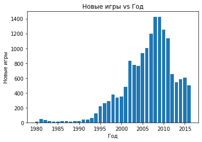

```python
# Анализ количества выхода новых игр от года
year_count = data.pivot_table(index = 'year_of_release', values = 'platform', aggfunc = 'count')
display(year_count)

plt.bar(year_count.index, year_count.platform)
plt.xlabel('Год')
plt.ylabel('Новые игры')
plt.title('Новые игры vs Год')
plt.show()
```

Количество выхода новых игр выросло на два порядка, начиная с 1980 года (9), и составило 1427 в 2008 году, а затем пошло на спад после 2009 года и стабилизировалось около 2012 года в дипапзоне 500-655 игр в год. За последние годы можно наблюдать цикличность ростов и спадов с периодом по 4-5 лет (2001-2006, 2006-2011, 2012-2016). Данные за 2016 год могут быть неполными, согласно входной информации.

| platform | world_sales |
| --- | --- |
| PS2 | 1255.77 |
| X360 | 971.42 |
| PS3 | 939.65 |
| Wii | 907.51 |
| DS | 806.12 |
| PS | 730.86 |
| GBA | 317.85 |
| PS4 | 314.14 |
| PSP | 294.05 |
| PC | 259.52 |

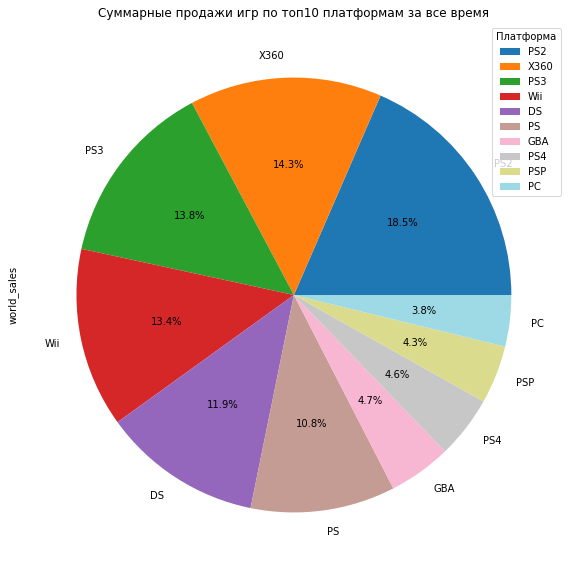

```python
# Анализ продаж по платформам

# Поиск топ10 платформ по суммарным мировым продажам за все время
top_world_sales_platforms = data.pivot_table(index = 'platform', values = 'world_sales', aggfunc = 'sum')
top10 = top_world_sales_platforms.sort_values(by = 'world_sales', ascending = False).index[:10]

display(top_world_sales_platforms.sort_values(by = 'world_sales', ascending = False).head(10))

# Анализ доли мировых продаж консолей из топ10
cmap = plt.get_cmap('tab20')
custom_labels = top10

top_world_sales_platforms.sort_values(by = 'world_sales', ascending = False).head(10)['world_sales'].plot(kind='pie', figsize=(20, 10), colormap=cmap, autopct='%1.1f%%', labels = custom_labels)
plt.legend(custom_labels, title='Платформа')
plt.title('Суммарные продажи игр по топ10 платформам за все время')
```

| year_of_release | platform | world_sales |
| --- | --- | --- |
| 2013 | PSP | 3.14 |
|  | Wii | 8.59 |
|  | X360 | 88.58 |
| 2014 | PC | 13.28 |
|  | PS3 | 47.76 |
|  | PS4 | 100.00 |
|  | PSP | 0.24 |
|  | Wii | 3.75 |
|  | X360 | 34.74 |
| 2015 | PC | 8.52 |
|  | PS3 | 16.82 |
|  | PS4 | 118.90 |
|  | PSP | 0.12 |
|  | Wii | 1.14 |
|  | X360 | 11.96 |
| 2016 | PC | 5.25 |
|  | PS3 | 3.60 |
|  | PS4 | 69.25 |
|  | Wii | 0.18 |
|  | X360 | 1.52 |

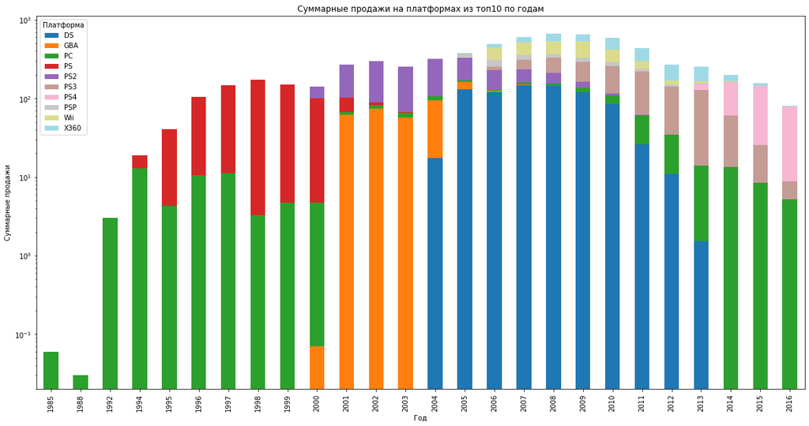

```python
# Создание таблицы с данными мировых продаж платформ из списка топ10 по годам
platform_count = data[data['platform'].isin(top10)].pivot_table(index = ['year_of_release', 'platform'], values = 'world_sales', aggfunc = 'sum')
display(platform_count.tail(20))

# Столбчатая диаграмма
cmap = plt.get_cmap('tab20')
platform_count.unstack().plot(kind='bar', figsize=(20, 10), stacked=True, colormap=cmap)

custom_labels = platform_count.index.levels[1]
plt.legend(custom_labels, title='Платформа')
plt.xlabel('Год')
plt.ylabel('Суммарные продажи')
plt.title('Суммарные продажи на платформах из топ10 по годам')
plt.yscale('log')
```

Составлен список топ10 платформ по суммарным продажам и построена столбчатая диаграмма распределения мировых продаж этих платформ по годам. Судя по графику можно сказать, что цикл жизни платформы из топ10 длится до 10 лет.

Логичнее всего выглядит построение прогноза продаж в 2017 году по интервалу по нескольким предыдущим годам, а не по одному году, учитывая динамику, а также жизненный цикл платформ. Также имеет смысл не учитывать 2016 год ввиду неполноты его данных. Итого, наиболее релевантными выглядят 4 года (2012-2015).

| year_of_release | platform | world_sales |
| --- | --- | --- |
| 2014 | 3DS | 43.76 |
|  | PC | 13.28 |
|  | PS3 | 47.76 |
|  | PS4 | 100.00 |
|  | PSP | 0.24 |
|  | PSV | 11.90 |
|  | Wii | 3.75 |
|  | WiiU | 22.03 |
|  | X360 | 34.74 |
|  | XOne | 54.07 |
| 2015 | 3DS | 27.78 |
|  | PC | 8.52 |
|  | PS3 | 16.82 |
|  | PS4 | 118.90 |
|  | PSP | 0.12 |
|  | PSV | 6.25 |
|  | Wii | 1.14 |
|  | WiiU | 16.35 |
|  | X360 | 11.96 |
|  | XOne | 60.14 |

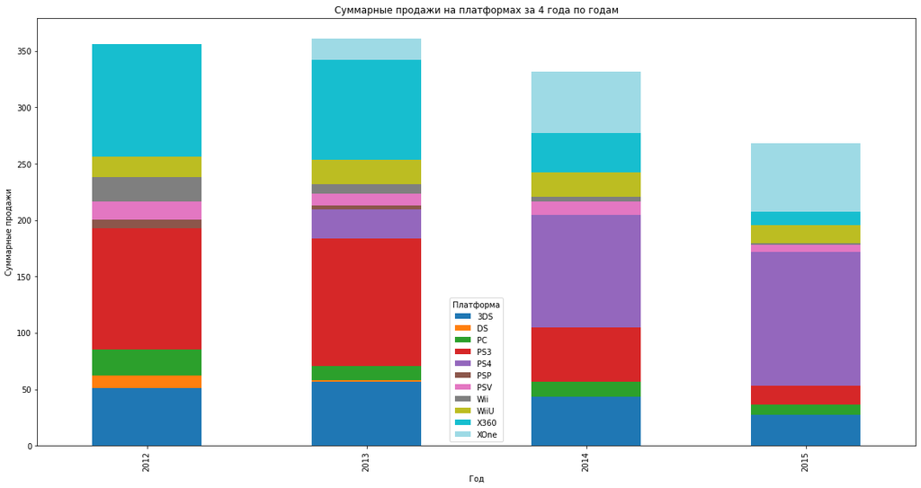

```python
# Формирование таблицы с актуальными данными за последние 5 лет
start_year = 2012
end_year = 2015

data_recent = data[(data['year_of_release'] >= start_year) & (data['year_of_release'] <= end_year)]

# Создание таблицы с данными мировых продаж платформ из списка топ10 по годам
world_sales_recent = data_recent.pivot_table(index = ['year_of_release', 'platform'], values = 'world_sales', aggfunc = 'sum')
display(world_sales_recent.tail(20))

cmap = plt.get_cmap('tab20')
world_sales_recent.unstack().plot(kind='bar', figsize=(20, 10), stacked=True, colormap=cmap)

custom_labels = world_sales_recent.index.levels[1]
plt.legend(custom_labels, title='Платформа')
plt.xlabel('Год')
plt.ylabel('Суммарные продажи')
plt.title(f'Суммарные продажи на платформах за {end_year-start_year+1} года по годам')
```

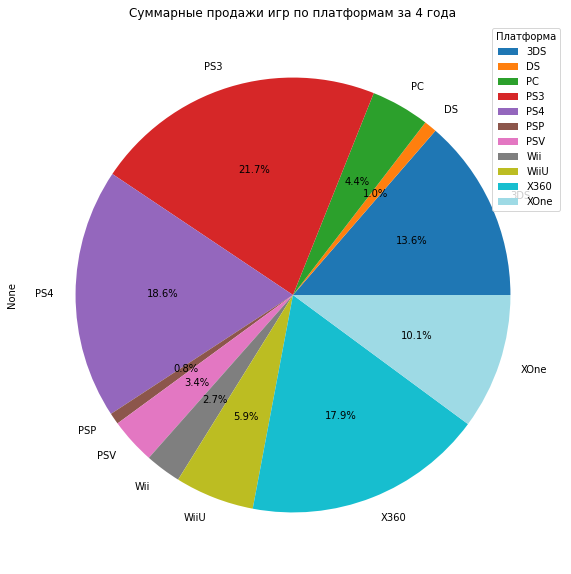

```python
# Анализ доли мировых продаж консолей из топ10
cmap = plt.get_cmap('tab20')
custom_labels = world_sales_recent.index.levels[1]
world_sales_recent.unstack().sum().plot(kind='pie', figsize=(20, 10), colormap=cmap, autopct='%1.1f%%', labels = custom_labels)
plt.legend(custom_labels, title='Платформа')
plt.title(f'Суммарные продажи игр по платформам за {end_year-start_year+1} года')
```

Суммарно за последние 4 года лидерами мировых продаж стали PS3, PS4, X360, 3DS и XOne в порядке убывания доли.

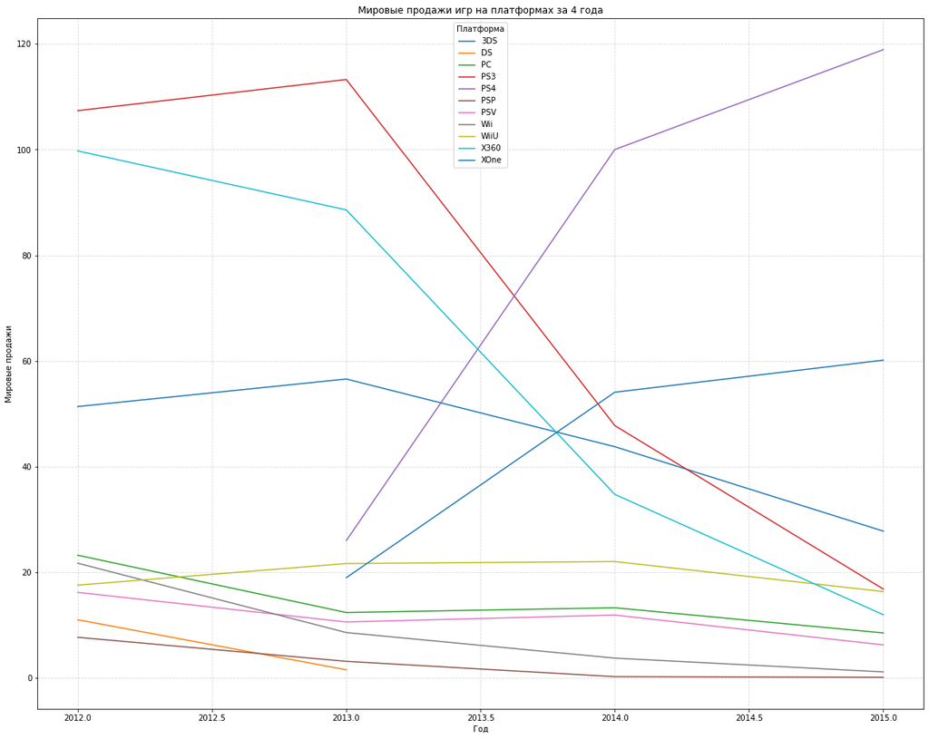

```python
plt.figure(figsize=(20, 16))
plt.plot(world_sales_recent.unstack())
custom_labels = world_sales_recent.index.levels[1]
plt.legend(custom_labels, title='Платформа')
plt.xlabel('Год')
plt.ylabel('Мировые продажи')
plt.title(f'Мировые продажи игр на платформах за {end_year-start_year+1} года')
plt.grid(True, linestyle='--', alpha=0.5)
```

Почти все платформы испытывают падение мировых продаж в последние годы. Лишь XOne и PS4 (две молодые платформы) выросли относительно 2013 года (дата появления первых продаж под эти платформы). Вероятнее всего, в ближайшие годы они будут иметь большие продажи и занимать все большую долю рынка.

| platform | world_sales |
| --- | --- |
| XOne | 0.350 |
| X360 | 0.340 |
| PS4 | 0.310 |
| PS3 | 0.230 |
| WiiU | 0.220 |
| Wii | 0.180 |
| 3DS | 0.115 |
| PC | 0.100 |
| PSV | 0.060 |
| DS | 0.050 |
| PSP | 0.030 |

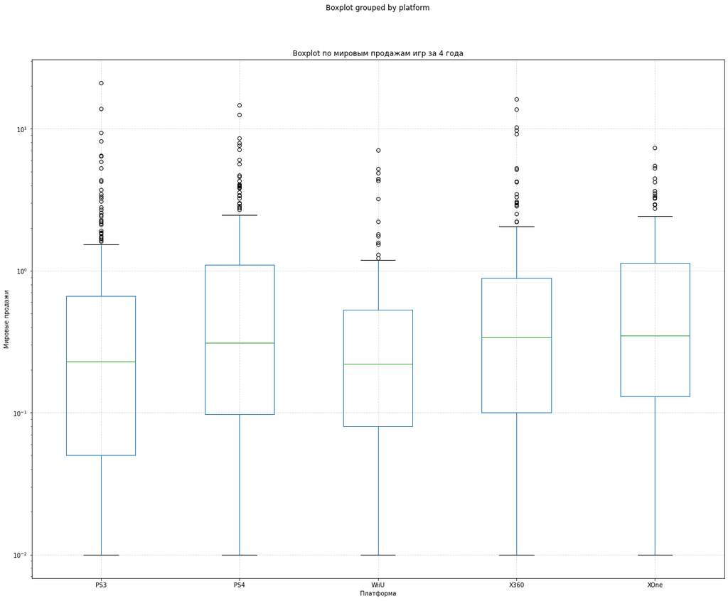

| platform | world_sales |
| --- | --- |
| XOne | 0.35 |
| X360 | 0.34 |
| PS4 | 0.31 |
| PS3 | 0.23 |
| WiiU | 0.22 |

```python
display(data_recent.pivot_table(index = ['platform'], values = 'world_sales', aggfunc = 'median').sort_values(by = 'world_sales', ascending = False))

top5_platform = data_recent.pivot_table(index = ['platform'], values = 'world_sales', aggfunc = 'median').sort_values(by = 'world_sales', ascending = False).head(5).index

# Создаем график «ящик с усами» по мировым продажам игр за актуальный период в разбивке по 5 перспективным платформам
plt.figure(figsize=(20, 16))
data_recent[data_recent['platform'].isin(top5_platform)].boxplot(column='world_sales', by='platform', figsize=(20, 16))  # Разбивка по параметру 'day' и анализ параметра 'total_bill'
plt.title(f'Boxplot по мировым продажам игр за {end_year-start_year+1} года')
plt.xlabel('Платформа')
plt.ylabel('Мировые продажи')
plt.yscale('log')
plt.grid(True, linestyle='--', alpha=0.5)
plt.show()

display(data_recent.pivot_table(index = ['platform'], values = 'world_sales', aggfunc = 'median').sort_values(by = 'world_sales', ascending = False).head(5))
```

Медианные значения могут отличаться между платформами на порядок, например, PSP и XOne. Наиболее продаваемые игры (по медианному значению) выходят на XOne, X360, PS4, PS3, WiiU (топ5 перспективных для 2017 года платформ), три наименее продаваемые (по медианному значению) - на PSP, DS и PSV.

У каждой платформы встречаются игры с аномально высокими мировыми продажами за верхним усом, но нет аномально низких продаж.

Оценим, как влияют на продажи внутри одной популярной платформы отзывы пользователей и критиков.

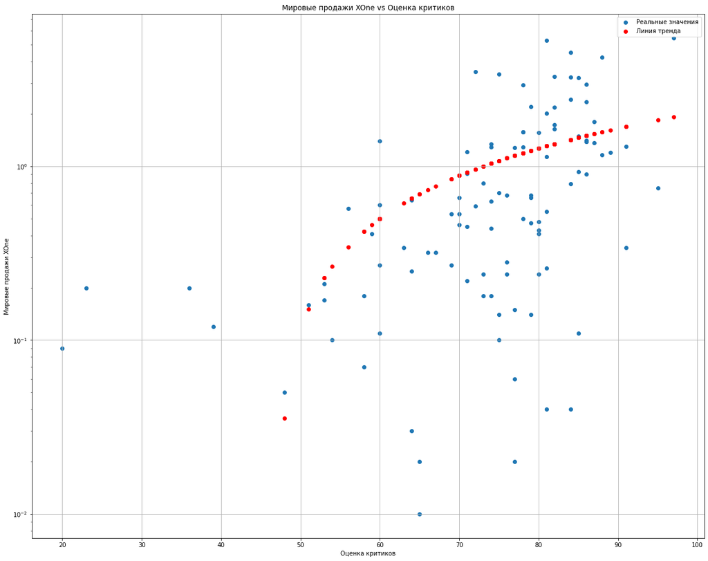

```
Коэффициент корреляции между мировыми продажами игр под XOne и оценкой критиков 0.4456109327504765
```

```python
# Оценка влияния отзывов критиков на мировые продажи XOne
x = data_recent[(data['platform'] == 'XOne')].dropna()['critic_score']
y = data_recent[(data['platform'] == 'XOne')].dropna()['world_sales']


plt.figure(figsize=(20, 16))
plt.scatter(x, y)
slope, intercept = np.polyfit(x, y, 1)
trendline = [slope * xi + intercept for xi in x]
plt.scatter(x, trendline, color='red')
plt.xlabel('Оценка критиков')
plt.ylabel('Мировые продажи XOne')
plt.title('Мировые продажи XOne vs Оценка критиков')
plt.legend(['Реальные значения', 'Линия тренда'])
plt.grid(True)
plt.yscale('log')
plt.show()


correlation = y.corr(x)
print('Коэффициент корреляции между мировыми продажами игр под XOne и оценкой критиков', correlation)
```

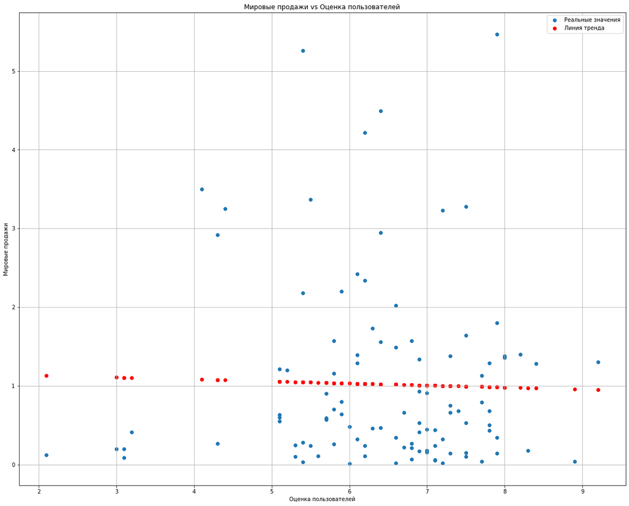

```
Коэффициент корреляции между мировыми продажами игр под XOne и оценкой пользователей -0.027820394382517852
```

```python
# Оценка влияния отзывов пользователей на мировые продажи XOne
x = data_recent[(data['platform'] == 'XOne')].dropna()['user_score']
y = data_recent[(data['platform'] == 'XOne')].dropna()['world_sales']

plt.figure(figsize=(20, 16))
plt.scatter(x, y)
slope, intercept = np.polyfit(x, y, 1)
trendline = [slope * xi + intercept for xi in x]
plt.scatter(x, trendline, color='red')
plt.xlabel('Оценка пользователей')
plt.ylabel('Мировые продажи')
plt.title('Мировые продажи vs Оценка пользователей')
plt.legend(['Реальные значения', 'Линия тренда'])
plt.grid(True)
plt.show()

correlation = y.corr(x)
print('Коэффициент корреляции между мировыми продажами игр под XOne и оценкой пользователей', correlation)
```

На примере продаж игр на XOne обнаружена положительная корреляция между мировыми продажами и оценками критиков и отсутствие корреляции между мировыми продажами и оценками пользователей, которые также явно видны на диаграммах рассеяния.

```python
# Влияние оценок пользователей на продажи других платформ
user_score_effect = []
for plat in data_recent['platform'].unique():
    x = data_recent[(data['platform'] == plat)]['user_score']
    y = data_recent[(data['platform'] == plat)]['world_sales']
    correlation = y.corr(x)
    user_score_effect.append(correlation)
    print(f'Коэффициент корреляции между мировыми продажами игр под {plat} и оценкой пользователей', correlation)
    print('Количество игр с оценкой', len(x))
    print('Количество разных видов оценок', len(x.unique()))
```

```
Коэффициент корреляции между мировыми продажами игр под PS3 и оценкой пользователей -0.0217136781004433
Количество игр с оценкой 455
Количество разных видов оценок 62
Коэффициент корреляции между мировыми продажами игр под X360 и оценкой пользователей -0.009605025034522971
Количество игр с оценкой 279
Количество разных видов оценок 62
Коэффициент корреляции между мировыми продажами игр под PS4 и оценкой пользователей 0.024230832360622553
Количество игр с оценкой 228
Количество разных видов оценок 51
Коэффициент корреляции между мировыми продажами игр под 3DS и оценкой пользователей 0.21056681222463666
Количество игр с оценкой 350
Количество разных видов оценок 47
Коэффициент корреляции между мировыми продажами игр под DS и оценкой пользователей 0.88270872757644
Количество игр с оценкой 31
Количество разных видов оценок 4
Коэффициент корреляции между мировыми продажами игр под XOne и оценкой пользователей -0.03926828544552199
Количество игр с оценкой 160
Количество разных видов оценок 42
Коэффициент корреляции между мировыми продажами игр под WiiU и оценкой пользователей 0.41326541780286724
Количество игр с оценкой 133
Количество разных видов оценок 46
Коэффициент корреляции между мировыми продажами игр под Wii и оценкой пользователей 0.2961968000747953
Количество игр с оценкой 53
Количество разных видов оценок 16
Коэффициент корреляции между мировыми продажами игр под PC и оценкой пользователей -0.15922791823300494
Количество игр с оценкой 196
Количество разных видов оценок 56
Коэффициент корреляции между мировыми продажами игр под PSV и оценкой пользователей 0.013595367007283735
Количество игр с оценкой 326
Количество разных видов оценок 39
Коэффициент корреляции между мировыми продажами игр под PSP и оценкой пользователей -0.802302061939321
Количество игр с оценкой 173
Количество разных видов оценок 5
```

```python
critic_score_effect = []
for plat in data_recent['platform'].unique():
    x = data_recent[(data['platform'] == plat)]['critic_score']
    y = data_recent[(data['platform'] == plat)]['world_sales']
    correlation = y.corr(x)
    critic_score_effect.append(correlation)
    print(f'Коэффициент корреляции между мировыми продажами игр под {plat} и оценкой критиков', correlation)
    print('Количество игр с оценкой', len(x))
    print('Количество разных видов оценок', len(x.unique()))
```

```
Коэффициент корреляции между мировыми продажами игр под PS3 и оценкой критиков 0.3314972592629587
Количество игр с оценкой 455
Количество разных видов оценок 56
Коэффициент корреляции между мировыми продажами игр под X360 и оценкой критиков 0.36057348885073365
Количество игр с оценкой 279
Количество разных видов оценок 53
Коэффициент корреляции между мировыми продажами игр под PS4 и оценкой критиков 0.4318482049982005
Количество игр с оценкой 228
Количество разных видов оценок 47
Коэффициент корреляции между мировыми продажами игр под 3DS и оценкой критиков 0.3331477996346886
Количество игр с оценкой 350
Количество разных видов оценок 42
Коэффициент корреляции между мировыми продажами игр под DS и оценкой критиков nan
Количество игр с оценкой 31
Количество разных видов оценок 2
Коэффициент корреляции между мировыми продажами игр под XOne и оценкой критиков 0.4593845680707106
Количество игр с оценкой 160
Количество разных видов оценок 43
Коэффициент корреляции между мировыми продажами игр под WiiU и оценкой критиков 0.3546914930621983
Количество игр с оценкой 133
Количество разных видов оценок 45
Коэффициент корреляции между мировыми продажами игр под Wii и оценкой критиков -0.4243413011077495
Количество игр с оценкой 53
Количество разных видов оценок 5
Коэффициент корреляции между мировыми продажами игр под PC и оценкой критиков 0.26315662774565857
Количество игр с оценкой 196
Количество разных видов оценок 44
```

```
Коэффициент корреляции между мировыми продажами игр под PSV и оценкой критиков 0.11612141423161347
Количество игр с оценкой 326
Количество разных видов оценок 39
Коэффициент корреляции между мировыми продажами игр под PSP и оценкой критиков nan
Количество игр с оценкой 173
Количество разных видов оценок 2
```

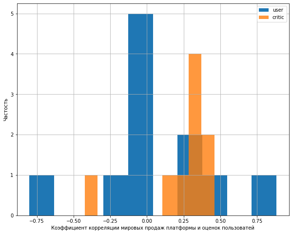

```python
plt.figure(figsize=(10, 8))
plt.hist(user_score_effect)
plt.hist(critic_score_effect, alpha = 0.8)
plt.xlabel('Коэффициент корреляции мировых продаж платформы и оценок пользоватей')
plt.ylabel('Частость')
plt.grid(True)
plt.legend(['user', 'critic'])
plt.show()
```

Можно сделать вывод о том, что оценки пользователей чаще не оказывают влияния или оказывает слабое влияние на мировые продажи игр, но есть исключения - продажи игр под DS очень сильно коррелируют с оценками, тогда как под PSP имеют очень сильную отрицательную корреляцию.

Оценки критиков чаще слабо положительно коррелируют с мировыми продажами игр, но есть исключение - продажи под Wii обратно коррелируют с оценками критиков. Кроме того, для игр под DS и PSP не удалось установить корреляцию мировых продаж с оценками критиков в виду отсутствия достаточного количества данных.

| genre | games_number | median_world_sales | sum_world_sales |
| --- | --- | --- | --- |
| Shooter | 188 | 0.525 | 266.51 |
| Sports | 220 | 0.305 | 157.58 |
| Platform | 70 | 0.285 | 57.77 |
| Racing | 91 | 0.230 | 50.71 |
| Misc | 160 | 0.180 | 82.44 |
| Fighting | 93 | 0.160 | 40.02 |
| Role-Playing | 316 | 0.150 | 174.62 |
| Simulation | 62 | 0.150 | 33.23 |
| Action | 853 | 0.140 | 411.01 |
| Strategy | 58 | 0.080 | 12.21 |
| Puzzle | 27 | 0.050 | 4.88 |
| Adventure | 246 | 0.030 | 25.61 |

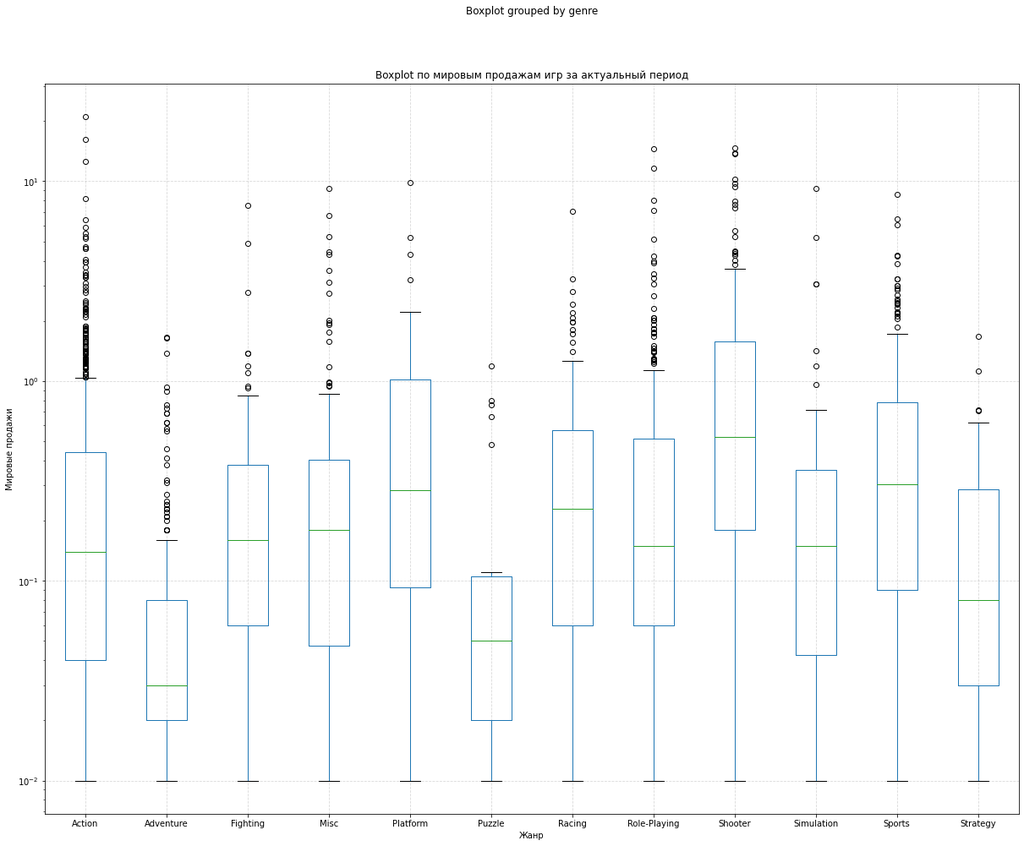

```python
# Поиск прибыльных и малоприбыльных жанров
data_genre = data_recent.pivot_table(index = ['genre'], values = 'world_sales', aggfunc = ['count', 'median', 'sum'])
data_genre.columns = ['games_number', 'median_world_sales', 'sum_world_sales']
display(data_genre.sort_values(by = 'median_world_sales', ascending = False))

plt.figure(figsize=(20, 16))
data_recent.boxplot(column='world_sales', by='genre', figsize=(20, 16))
plt.title('Boxplot по мировым продажам игр за актуальный период')
plt.xlabel('Жанр')
plt.ylabel('Мировые продажи')
plt.yscale('log')
plt.grid(True, linestyle='--', alpha=0.5)
plt.show()
```

Наиболее высокие медианные продажи наблюдаются у Shooter (0.525), Sports (0.305), Platform (0.285), Racing (0.23) и Misc (0.18).

Жанры с Puzzle, Strategy, Adventure имеют самые низкие медианы продаж: 0.05, 0.08, 0.03, соответственно.

## Портрет пользователя каждого региона

Определяем портрет пользователя каждого региона (NA, EU, JP)

| platform | games_number | median_sales | sum_sales |
| --- | --- | --- | --- |
| X360 | 279 | 0.180 | 139.36 |
| PS3 | 455 | 0.060 | 102.71 |
| PS4 | 228 | 0.105 | 87.25 |
| XOne | 160 | 0.220 | 78.85 |
| 3DS | 350 | 0.000 | 51.17 |

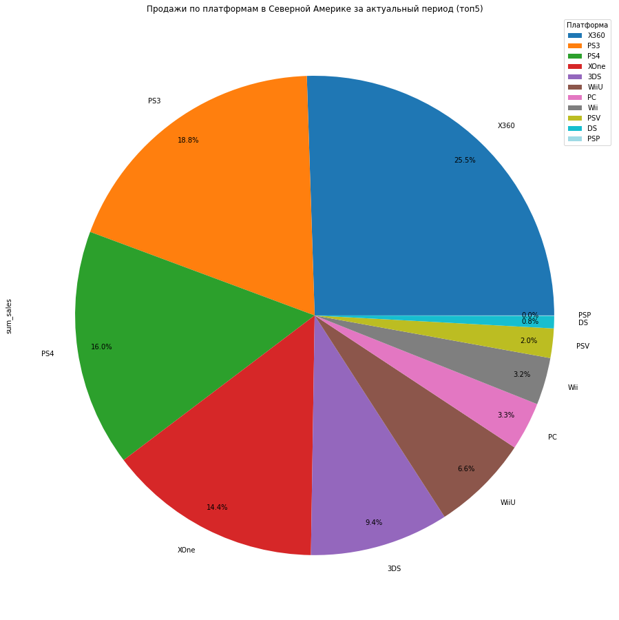

```python
# Находим самые популярные платформы (топ-5) для рынка Северной Америки
data_platform_na = data_recent.pivot_table(index = ['platform'], values = 'na_sales', aggfunc = ['count', 'median', 'sum'])
data_platform_na.columns = ['games_number', 'median_sales', 'sum_sales']
data_platform_na = data_platform_na.sort_values(by = 'sum_sales', ascending = False)
display(data_platform_na.head(5))

cmap = plt.get_cmap('tab20')
custom_labels = data_platform_na.index
data_platform_na['sum_sales'].plot(kind='pie', figsize=(20, 16), colormap=cmap, autopct='%1.1f%%', labels = custom_labels, pctdistance=0.9)
plt.legend(custom_labels, title='Платформа', loc="best")
plt.title('Продажи по платформам в Северной Америке за актуальный период (топ5)')
```

| platform | games_number | median_sales | sum_sales |
| --- | --- | --- | --- |
| PS4 | 228 | 0.13 | 109.31 |
| PS3 | 455 | 0.03 | 105.60 |
| X360 | 279 | 0.11 | 73.81 |
| XOne | 160 | 0.11 | 41.96 |
| 3DS | 350 | 0.00 | 40.31 |

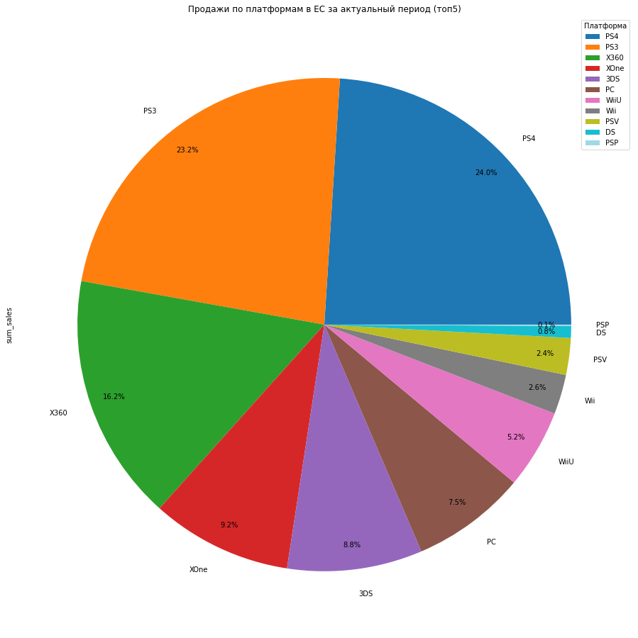

```python
# Находим самые популярные платформы (топ-5) для рынка Евросоюза
data_platform_eu = data_recent.pivot_table(index = ['platform'], values = 'eu_sales', aggfunc = ['count', 'median', 'sum'])
data_platform_eu.columns = ['games_number', 'median_sales', 'sum_sales']
data_platform_eu = data_platform_eu.sort_values(by = 'sum_sales', ascending = False)
display(data_platform_eu.head(5))

cmap = plt.get_cmap('tab20')
custom_labels = data_platform_eu.index

data_platform_eu['sum_sales'].plot(kind='pie', figsize=(20, 16), colormap=cmap, autopct='%1.1f%%', labels = custom_labels, pctdistance=0.9)
plt.legend(custom_labels, title='Платформа', loc="best")
plt.title('Продажи по платформам в ЕС за актуальный период (топ5)')
```

| platform | games_number | median_sales | sum_sales |
| --- | --- | --- | --- |
| 3DS | 350 | 0.06 | 79.76 |
| PS3 | 455 | 0.03 | 33.99 |
| PSV | 326 | 0.03 | 17.48 |
| WiiU | 133 | 0.00 | 12.34 |
| PSP | 173 | 0.03 | 10.47 |

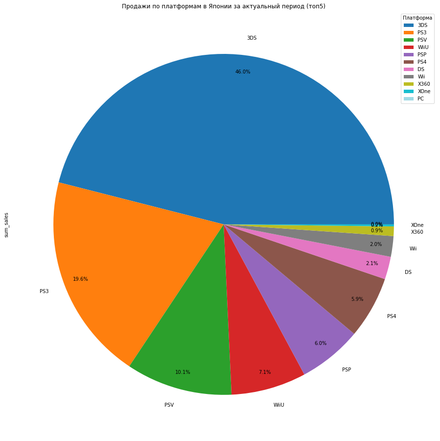

```python
# Находим самые популярные платформы (топ-5) для рынка Японии
data_platform_jp = data_recent.pivot_table(index = ['platform'], values = 'jp_sales', aggfunc = ['count', 'median', 'sum'])
data_platform_jp.columns = ['games_number', 'median_sales', 'sum_sales']
data_platform_jp = data_platform_jp.sort_values(by = 'sum_sales', ascending = False)
display(data_platform_jp.head(5))

cmap = plt.get_cmap('tab20')
custom_labels = data_platform_jp.index

data_platform_jp['sum_sales'].plot(kind='pie', figsize=(20, 16), colormap=cmap, autopct='%1.1f%%', labels = custom_labels, pctdistance=0.9)
plt.legend(custom_labels, title='Платформа', loc="best")
plt.title('Продажи по платформам в Японии за актуальный период (топ5)')
```

На рынке Северной Америке и Евросоюза топ5 платформы: X360, PS3, PS4, XOne, 3DS, но в разном соотношении.

Топ5 Японии - 3DS, PS3, PSV, WiiU и PSP.

| genre | games_number | median_sales | sum_sales |
| --- | --- | --- | --- |
| Action | 853 | 0.030 | 168.55 |
| Shooter | 188 | 0.220 | 128.53 |
| Sports | 220 | 0.100 | 73.99 |
| Role-Playing | 316 | 0.020 | 58.11 |
| Misc | 160 | 0.015 | 37.43 |

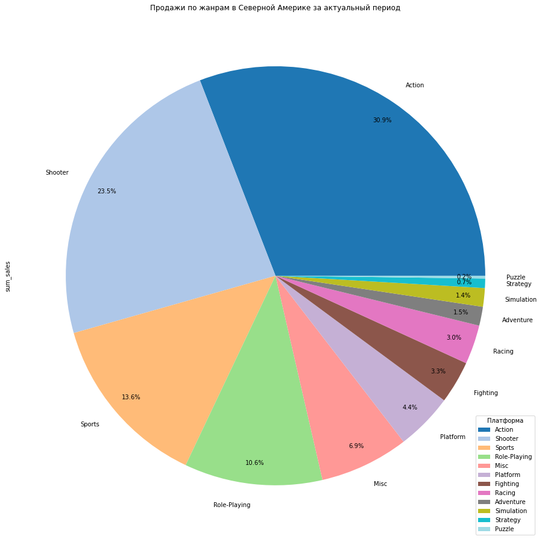

```python
# Находим самые популярные жанры (топ-5) для рынка Северной Америки
data_genre_na = data_recent.pivot_table(index = ['genre'], values = 'na_sales', aggfunc = ['count', 'median', 'sum'])
data_genre_na.columns = ['games_number', 'median_sales', 'sum_sales']
data_genre_na = data_genre_na.sort_values(by = 'sum_sales', ascending = False)
display(data_genre_na.head(5))

cmap = plt.get_cmap('tab20')
custom_labels = data_genre_na.index
data_genre_na['sum_sales'].plot(kind='pie', figsize=(20, 16), colormap=cmap, autopct='%1.1f%%', labels = custom_labels, pctdistance=0.9)
plt.legend(custom_labels, title='Платформа', loc="best")
plt.title('Продажи по жанрам в Северной Америке за актуальный период')
```

| genre | games_number | median_sales | sum_sales |
| --- | --- | --- | --- |
| Action | 853 | 0.030 | 148.66 |
| Shooter | 188 | 0.205 | 97.57 |
| Sports | 220 | 0.060 | 57.08 |
| Role-Playing | 316 | 0.010 | 44.25 |
| Misc | 160 | 0.025 | 25.66 |

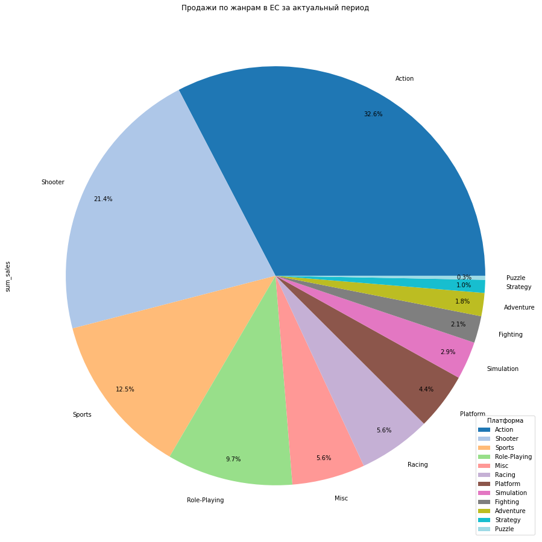

```python
# Находим самые популярные жанры (топ-5) для рынка Евросоюза
data_genre_eu = data_recent.pivot_table(index = ['genre'], values = 'eu_sales', aggfunc = ['count', 'median', 'sum'])
data_genre_eu.columns = ['games_number', 'median_sales', 'sum_sales']
data_genre_eu = data_genre_eu.sort_values(by = 'sum_sales', ascending = False)
display(data_genre_eu.head(5))

cmap = plt.get_cmap('tab20')
custom_labels = data_genre_eu.index
data_genre_eu['sum_sales'].plot(kind='pie', figsize=(20, 16), colormap=cmap, autopct='%1.1f%%', labels = custom_labels, pctdistance=0.9)
plt.legend(custom_labels, title='Платформа', loc="best")
plt.title('Продажи по жанрам в ЕС за актуальный период')
```

| genre | games_number | median_sales | sum_sales |
| --- | --- | --- | --- |
| Role-Playing | 316 | 0.06 | 58.83 |
| Action | 853 | 0.01 | 45.73 |
| Misc | 160 | 0.01 | 11.82 |
| Simulation | 62 | 0.00 | 10.08 |
| Fighting | 93 | 0.03 | 8.69 |

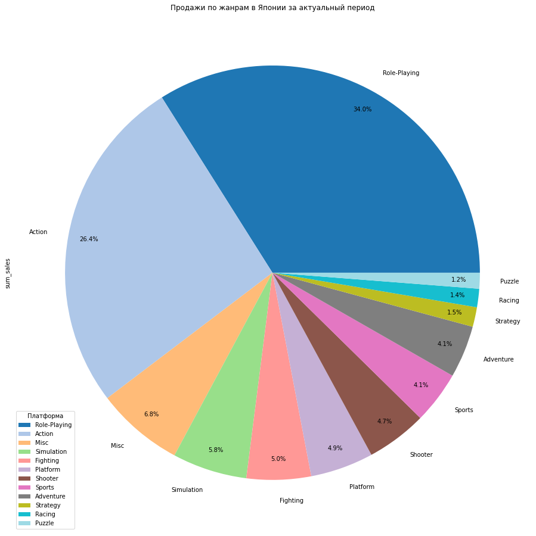

```python
# Находим самые популярные жанры (топ-5) для рынка Японии
data_genre_jp = data_recent.pivot_table(index = ['genre'], values = 'jp_sales', aggfunc = ['count', 'median', 'sum'])
data_genre_jp.columns = ['games_number', 'median_sales', 'sum_sales']
data_genre_jp = data_genre_jp.sort_values(by = 'sum_sales', ascending = False)
display(data_genre_jp.head(5))

cmap = plt.get_cmap('tab20')
custom_labels = data_genre_jp.index
data_genre_jp['sum_sales'].plot(kind='pie', figsize=(20, 16), colormap=cmap, autopct='%1.1f%%', labels = custom_labels, pctdistance=0.9)
plt.legend(custom_labels, title='Платформа', loc="best")
plt.title('Продажи по жанрам в Японии за актуальный период')
```

В Северной Америке и Евросоюзе самые популярные жанры - Action, Shooter, Sports, Role-Playing, Misc.

В Японии - Role-Playing, Action, Misc, Simulation, Fighting.

| rating | games_number | median_sales | sum_sales |
| --- | --- | --- | --- |
| E | 329 | 0.00 | 27.26 |
| T | 326 | 0.02 | 23.75 |
| M | 420 | 0.00 | 20.00 |
| E10+ | 256 | 0.00 | 7.74 |

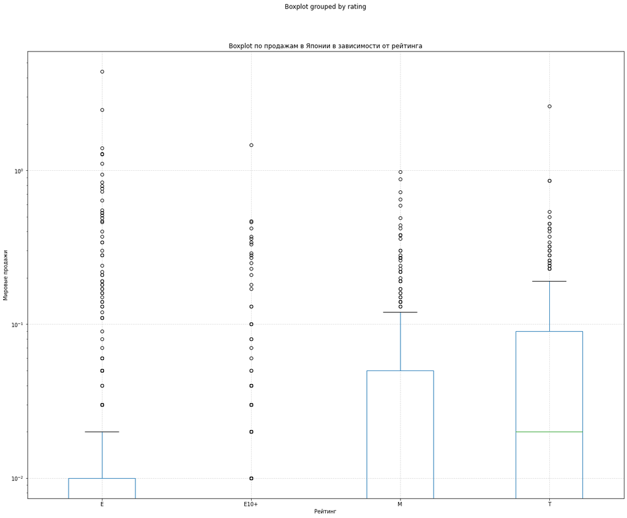

```python
# Определим, влияет ли рейтинг ESRB на продажи в отдельном регионе
data_rating = data_recent.pivot_table(index = ['rating'], values = 'jp_sales', aggfunc = ['count', 'median', 'sum'])
data_rating.columns = ['games_number', 'median_sales', 'sum_sales']
display(data_rating.sort_values(by = 'sum_sales', ascending = False))

plt.figure(figsize=(20, 16))
data_recent.boxplot(column='jp_sales', by='rating', figsize=(20, 16))
plt.title('Boxplot по продажам в Японии в зависимости от рейтинга')
plt.xlabel('Рейтинг')
plt.ylabel('Мировые продажи')
plt.yscale('log')
plt.grid(True, linestyle='--', alpha=0.5)
plt.show()
```

| rating | games_number | median_sales | sum_sales |
| --- | --- | --- | --- |
| M | 420 | 0.20 | 215.90 |
| E | 329 | 0.09 | 106.40 |
| E10+ | 256 | 0.17 | 71.89 |
| T | 326 | 0.06 | 57.07 |

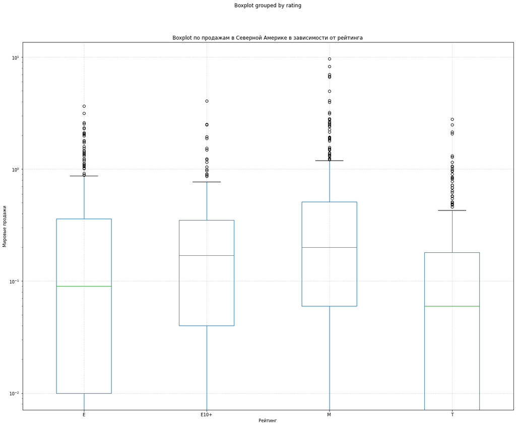

```python
data_rating = data_recent.pivot_table(index = ['rating'], values = 'na_sales', aggfunc = ['count', 'median', 'sum'])
data_rating.columns = ['games_number', 'median_sales', 'sum_sales']
display(data_rating.sort_values(by = 'sum_sales', ascending = False))

plt.figure(figsize=(20, 16))
data_recent.boxplot(column='na_sales', by='rating', figsize=(20, 16))

plt.title('Boxplot по продажам в Северной Америке в зависимости от рейтинга')
plt.xlabel('Рейтинг')
plt.ylabel('Мировые продажи')
plt.yscale('log')
plt.grid(True, linestyle='--', alpha=0.5)

plt.show()
```

| rating | games_number | median_sales | sum_sales |
| --- | --- | --- | --- |
| M | 420 | 0.15 | 177.42 |
| E | 329 | 0.08 | 99.42 |
| E10+ | 256 | 0.12 | 51.56 |
| T | 326 | 0.04 | 43.17 |

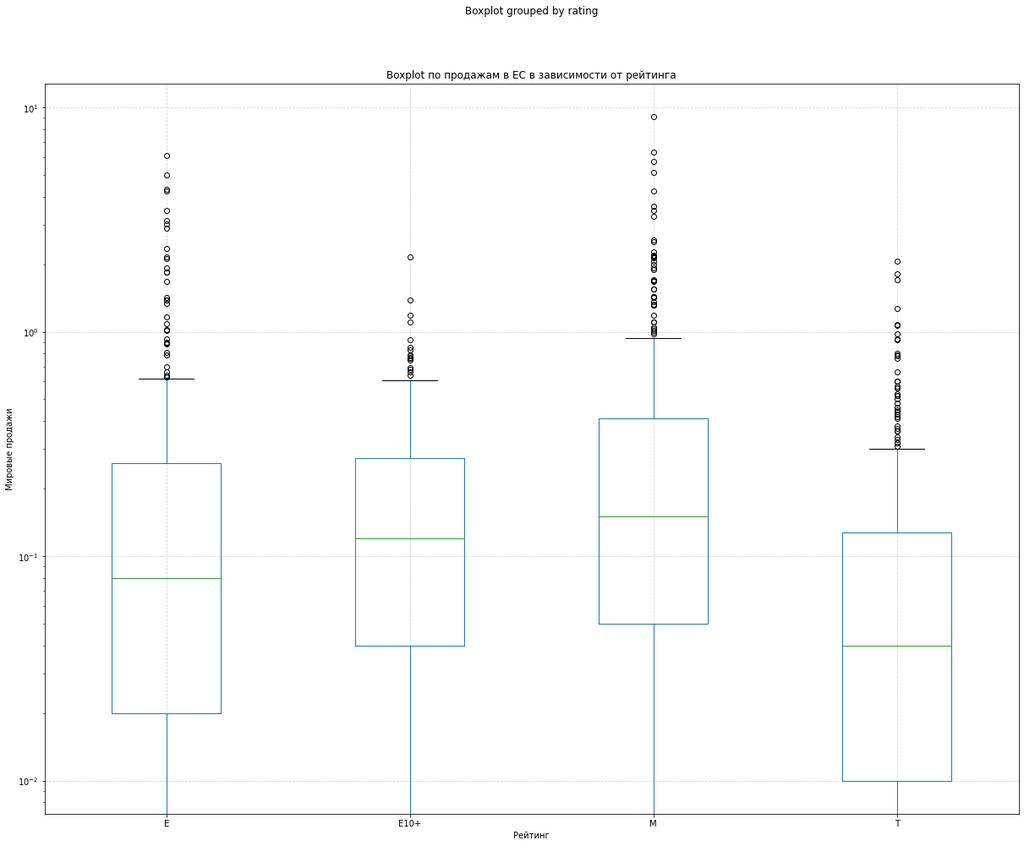

```python
data_rating = data_recent.pivot_table(index = ['rating'], values = 'eu_sales', aggfunc = ['count', 'median', 'sum'])
data_rating.columns = ['games_number', 'median_sales', 'sum_sales']

display(data_rating.sort_values(by = 'sum_sales', ascending = False))

plt.figure(figsize=(20, 16))
data_recent.boxplot(column='eu_sales', by='rating', figsize=(20, 16))  # Разбивка по параметру 'day' и анализ параметра 'total_bill'
plt.title('Boxplot по продажам в ЕС в зависимости от рейтинга')
plt.xlabel('Рейтинг')
plt.ylabel('Мировые продажи')
plt.yscale('log')
plt.grid(True, linestyle='--', alpha=0.5)
plt.show()
```

В Японии продажи слишком малы или информация отсутствует, чтобы делать выводы о влиянии рейтинга.

В Северной Америке и Европе лучше всех продаются игры с рейтингом М, хуже всех с рейтингом Т. Можно заключить, что рейтинг оказывает влияние на продажи игр в этих регионах.

## Проверка гипотез

Проверяем гипотезу о пользовательских рейтингах платформ Xbox One и PC.

Нулевая гипотеза: средние пользовательские рейтинги платформ Xbox One и PC одинаковые.

Альтернативная гипотеза: средние пользовательские рейтинги платформ Xbox One и PC неодинаковые.

```python
# Проверяем двухстороннюю гипотезу о пользовательских рейтингах платформ при помощи ttest_ind метода

data1 = data_recent.loc[data['platform'] == 'XOne']['user_score'].dropna()
data2 = data_recent.loc[data['platform'] == 'PC']['user_score'].dropna()
alpha = 0.05

t_stat, p_value = stats.ttest_ind(data1, data2, equal_var=False)

if p_value < alpha:
    print(f"Опровергаем нулевую гипотезу")
else:
    print("Не удалось отвергнуть нулевую гипотезу")

print(f"p-value: {p_value}")
```

```
Не удалось отвергнуть нулевую гипотезу
p-value: 0.9441751855931831
```

Не удалось опровергнуть нулевую гипотезу о равенстве пользовательских рейтингов - вероятнее всего, средние пользовательские рейтинги платформ Xbox One и PC одинаковые.

Проверяем гипотезу о пользовательских рейтингах жанров Action и Sports.

Нулевая гипотеза: средние пользовательские рейтинги жанры Action и Sports одинаковые.

Альтернативная гипотеза: средние пользовательские рейтинги жанров Action и Sports неодинаковые.

```python
# Проверяем двухстороннюю гипотезу о пользовательских рейтингах жанров при помощи ttest_ind метода
data1 = data_recent.loc[data['genre'] == 'Action']['user_score'].dropna()
data2 = data_recent.loc[data['genre'] == 'Sports']['user_score'].dropna()
alpha = 0.05

t_stat, p_value = stats.ttest_ind(data1, data2, equal_var=False)

if p_value < alpha:
    print(f"Опровергаем нулевую гипотезу")
else:
    print("Не удалось отвергнуть нулевую гипотезу")

print(f"p-value: {p_value}")
```

```
Опровергаем нулевую гипотезу
p-value: 2.7671307856639633e-18
```

Опровергаем нулевую гипотезу о равенстве пользовательских рейтингов - вероятнее всего, средние пользовательские рейтинги жанров Action и Sports разнятся.

Было проверено две гипотезы: о равенстве пользовательских рейтингах платформ Xbox One и PC и о равенстве пользовательских рейтингов жанров Action и Sports. Поскольку сравниваемые выборки можно оценивать как независимые и оценивались равенства значений, был применен метод stats.ttest_ind для двухсторонних гипотез.

Гипотезу о равенстве пользовательстких рейтингов платформ Xbox One и PC отвергнуть не удалось, гипотеза о равенстве пользовательских рейтингов жанров Action и Sports была опровергнута.

## Выводы

Датасет содержит данные о продажах игр на различные платформы по разным годам и в разных регионах.

Проведена предобработка данных по выявлению, анализу и обработке пропусков и дубликатов, добавлен столбец с мировыми продажами.

Проанализирована статистика выпуска игр по годам и эта же статистика агрегированно под топ10 по продажам платформ. В среднем срок жизни платформы составляет до 10 лет. Для прогноза актуальным периодом названы последние года с полной статистикой - 2012-2015.

В актуальный период демонстрируют рост молодые платформы XOne и PS4, продажи остальных уменьшаются. Тенденция должна сохраниться, поскольку платформы были созданы в 2013 году и период пика популярноси еще не пройден.

Проанализировано влияние оценок критиков и пользователей на продажи игры. Можно сделать вывод о том, что оценки пользователей чаще не оказывают влияния или оказывает слабое влияние на мировые продажи игр, оценки критиков чаще слабо положительно коррелируют с мировыми продажами игр.

Больше всего продаж в последние годы приносит жанр Action, самые высокие продажи делают игры жанра Shooter. Кроме них также значимые продажи наблюдаются в жанрах Role-Playing и Sports. Жанры с самой небольшой прибылью - Puzzle, Strategy, Adventure.

Проанализированы предпочтения пользователей в каждом из регионов (NA, EU, JP). На рынке Северной Америке и Евросоюза топ5 платформы: X360, PS3, PS4, XOne, 3DS. Топ5 Японии - 3DS, PS3, PSV, WiiU и PSP. В Северной Америке и Евросоюзе самые популярные жанры - Action, Shooter, Sports, Role-Playing, Misc. В Японии - Role-Playing, Action, Misc, Simulation, Fighting. В Японии продажи слишком малы или информация отсутствует, чтобы делать выводы о влиянии рейтинга. В Северной Америке и Европе лучше всех продаются игры с рейтингом М, хуже всех с рейтингом Т.

Было проверено две гипотезы: о равенстве пользовательских рейтингах платформ Xbox One и PC и о равенстве пользовательских рейтингов жанров Action и Sports. Поскольку сравниваемые выборки можно оценивать как независимые и оценивались равенства значений, был применен метод stats.ttest_ind для двухсторонних гипотез. Гипотезу о равенстве пользовательстких рейтингов платформ Xbox One и PC отвергнуть не удалось, гипотеза о равенстве пользовательских рейтингов жанров Action и Sports была опровергнута.